# Introduction to R

Session 3

# Session Overview

1. Functions in R
2. Bonus: Looking Inside Functions
3. Objects Revisited
4. Packages

# Functions

## Functions

We have already encountered several *functions* in R:

- `setwd()`
- `sqrt()`
- `print()`
- `seq()`
- `rep()`
- `rnorm()`

## Function Overview

A function consists of three parts:

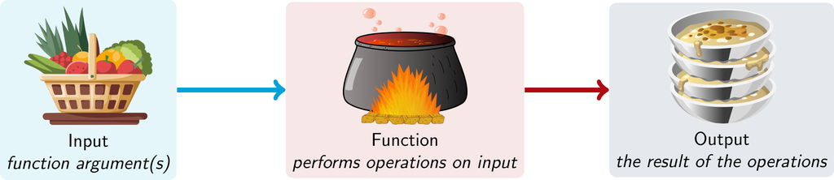

## Arguments

- A function is called by specifying the function name followed by one or more comma-separated arguments in parentheses:

```r
function_name(argument1 = value1, argument2 = value2, ...)
```

- This gives the same:

```r
function_name(argument2 = value2, argument1 = value1, ...)
```

- This also gives the same:

```r
function_name(value1, value2, ...)
```

- This does not!

```r
function_name(value2, value1, ...)
```

- Why?

## More about Arguments

- If you don’t give argument names, R assumes arguments are given in the order as defined.
- There are also default arguments, which do not always need to be specified.
- Let us look at an example: calculating the logarithm using the `log` function:

```r
fake_data <- c(1, 1, 2, 3, 5, 8, 13, 21)
log_exp_data <- log(fake_data)
log_2_data <- log(fake_data, base = 2)
```

**1**

Calculates the natural logarithm;

**2**

Calculates the logarithm with base 2.

- Use the help files to understand function arguments

## R help pages

- provide detailed descriptions, arguments, return values, etc. for R packages, functions
- include usage examples that demonstrate how to use the function effectively
- are directly accessible in RStudio

## R Help

Help files are displayed in the *Help* window in the bottom right window below

[figure not shown]

## Accessing R Help

To open the help file for a specific R function, for instance the function `log()`, you can use either of the following two commands:

```r
help(log)
?log
```

Both commands above to the same: they open the help file of the function you specified. Note that R searches for an **exact**! match and will only open the R Help page if the function exists.

## Exercise 3.1: R Help

- Execute the following code:

```r
?log
```

R should open the help page for the function with name `log`. No need to go over the help page in detail, we explore this in detail soon.

- Execute the following code:

```r
?logarithm
```

R should tell you that no documentation for the requested function exists. It did not find an **exact** match to the function `logarithm()`. It does give you a recommendation to try something instead…

- Namely to try this:

```r
??logarithm
```

R performs a full-text search of the help system for all documentation that mentions the term `logarithm`.

While the search with the command `?` is useful to directly access the help page of an R function you know exists, the broader help search with the command *??* is useful if you are not sure about the exact name of a function.

## Understanding the log function

Execute the command `?log`. It gives something like this:

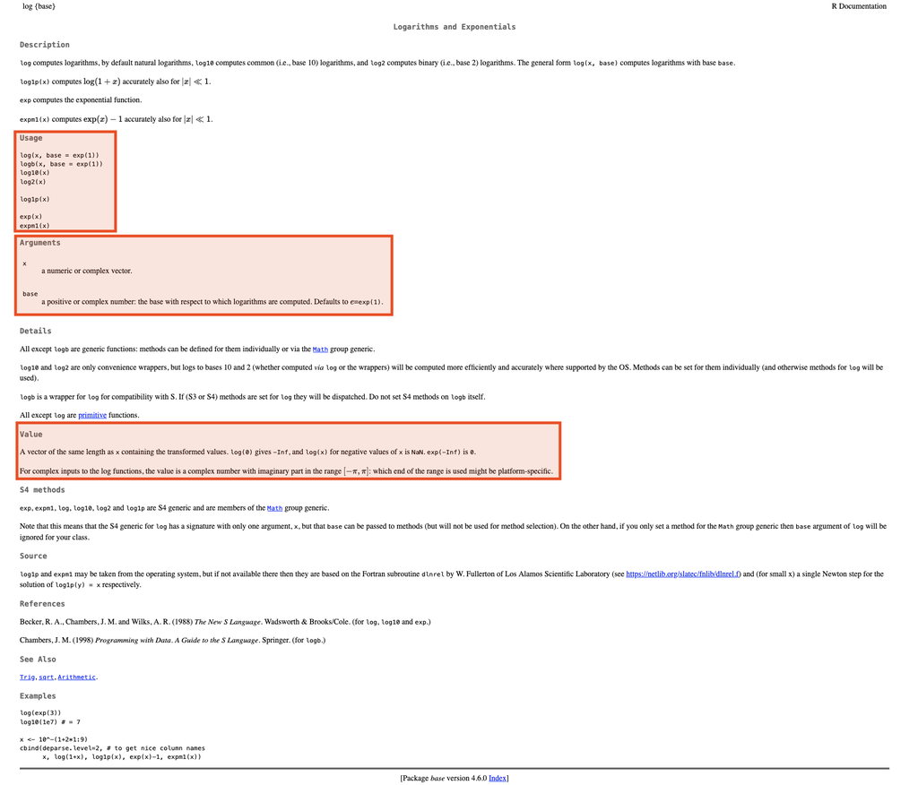

## Understanding the log function

Execute the command `?log`. It gives something like this:

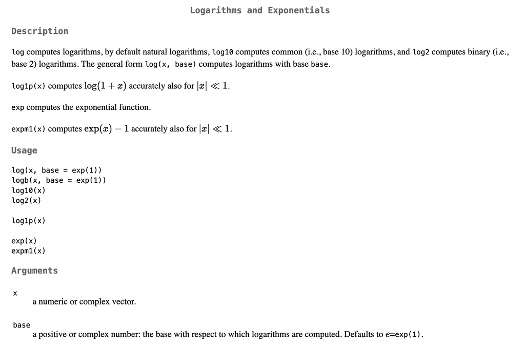

## Understanding the log function

Execute the command `?log`. It gives something like this:

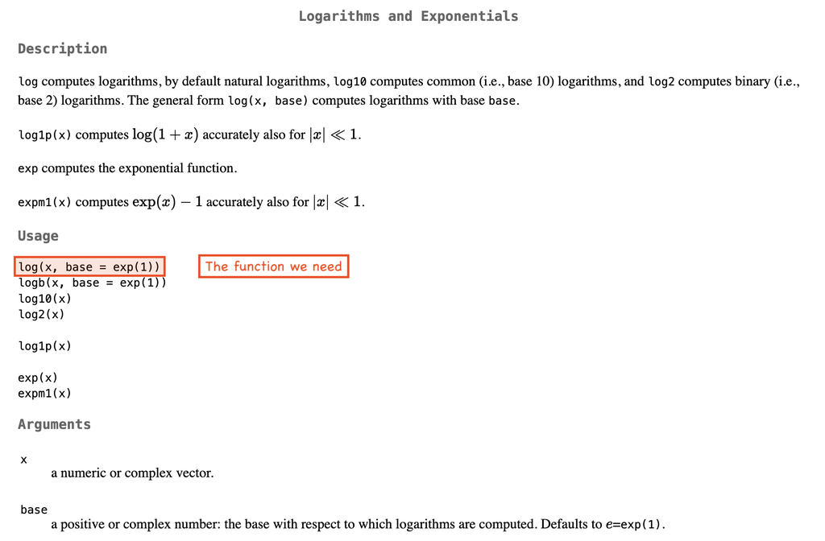

## Understanding the log function

Execute the command `?log`. It gives something like this:

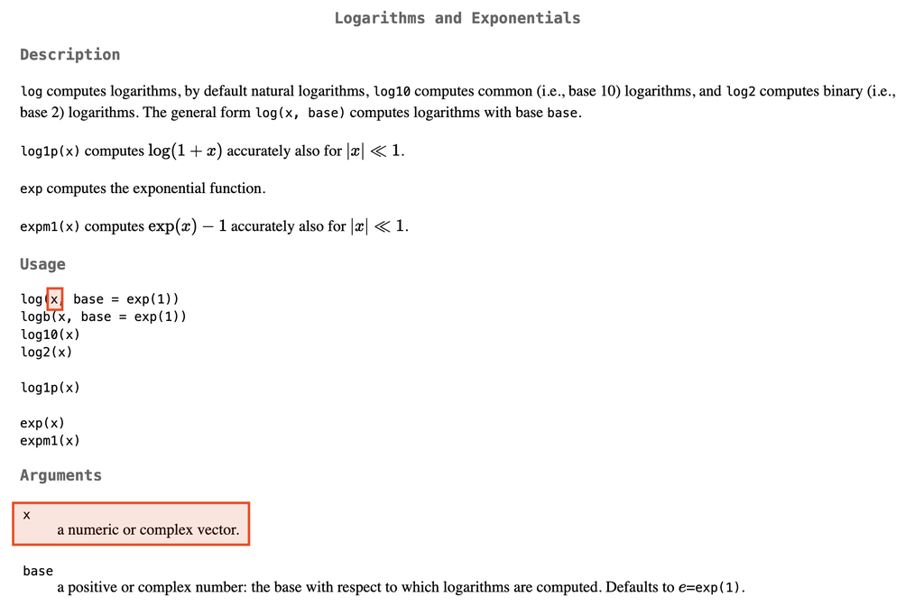

## Understanding the log function

Execute the command `?log`. It gives something like this:

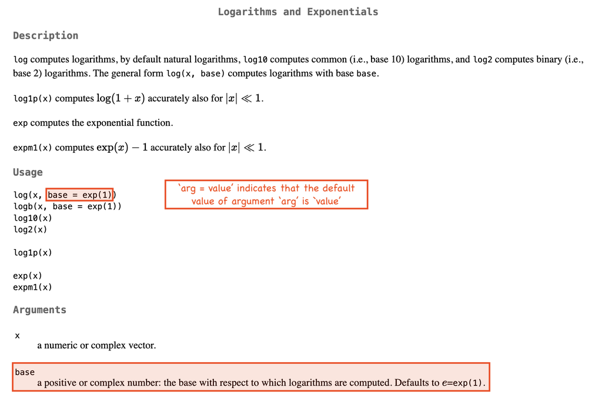

## Understanding the log function

Execute the command `?log`. It gives something like this:

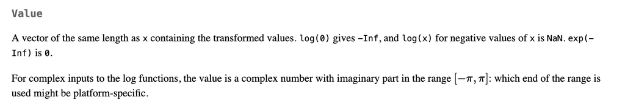

## Understanding the log function

Execute the command `?log`. It gives something like this:

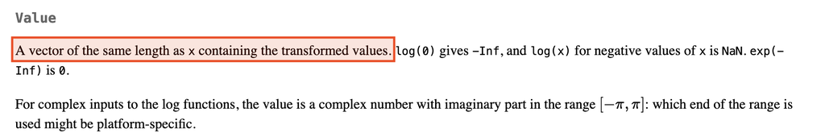

## Understanding the log function

Execute the command `?log`. It gives something like this:

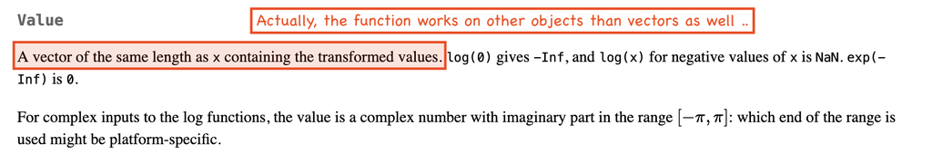

## Input and output of the log function

- Note how the `log` function preserves the object type of the input:

```r
fake_data <- c(1, 1, 2, 3, 5, 8, 13, 21)
log(fake_data)
```

```
[1] 0.0000000 0.0000000 0.6931472 1.0986123 1.6094379 2.0794415 2.5649494
[8] 3.0445224
```

```r
fake_data_matrix <- matrix(fake_data, nrow = 4)
log(fake_data_matrix)
```

```
          [,1]     [,2]
[1,] 0.0000000 1.609438
[2,] 0.0000000 2.079442
[3,] 0.6931472 2.564949
[4,] 1.0986123 3.044522
```

## Exercise 3.2: Function Arguments

The function `rnorm()` can be used to simulate normally distributed data. The function `mean()` can be used to calculate the sample mean of the data, while the function `sd()` can be used to calculate the sample standard deviation. You will need to use the help files of these functions to complete the question.

1. Simulate 100 numbers from a normal distribution with mean 0 and standard deviation 1 and store these in a vector called `x1`. Do this with the least amount of explicitly specified arguments as possible.
2. Simulate 200 numbers from a normal distribution with mean 0 and standard deviation 5 and store these in a vector called `x2`. Do this with the least amount of explicitly specified arguments as possible.
3. Simulate 80 numbers from a normal distribution with mean -6 and standard deviation 4 and store these in a vector called `x3`. Do this with the least amount of explicitly specified arguments as possible.
4. Calculate the mean and standard deviation of each of the three series.
5. Set the 10th value of `x1` to `NA`. Calculate the mean and standard deviation again. What do you observe? Learn from the help function how we can fix this.

## The … argument

- If you opened the help function of `mean()` before, you saw the last argument is “`...` further arguments passed to or from other methods”
- `...` is a special argument: it allows you to put in different arguments that are then passed on to an *other* function internally.
- To know how to put them correctly, you may need to look at the *other function*; not always easy!
- Since the function accepts any arguments in `...`, an error message will typically be given at a ‘deeper level’, which can be very confusing. Or you even may not get an error message at all.

## Exercise 3.2’: function arguments revisited

1. Repeat the last part of the previous exercise, calculating the standard deviation for `x1`. Make sure to name the second argument of the function explicitly. Now intentionally misspell the name of the second argument and look at the error message.
2. Now, do the same for calculating the mean; first do it correctly, then make an intentional mistake in the name of the argument.
3. Can you explain the difference in results?

## Useful functions: summary / descriptive statistics

- often you want to have a quick look at your data. Here are some useful functions for this purpose:
- For (numerical) vectors:

| Function | Description |
| --- | --- |
| `length(v)` | Number of elements in $v$ |
| `max(v)` | Largest value in $v$ |
| `min(v)` | Smallest value in $v$ |
| `sum(v)` | Sum of the elements of $v$ |
| `prod(v)` | Product of the elements of $v$ |
| `mean(v)` | mean of the elements of $v$! |
| `sd(v)` | Standard deviation of the elements of $v$ |

## Useful functions: summary / descriptive statistics

- Often you want to have a quick look at your data. Here are some useful functions for this purpose:
- For matrices and data frames:

| Function | Description |
| --- | --- |
| `nrow(D)` | Number of rows in $D$ |
| `ncol(D)` | Number of columns in $D$ |
| `head(D)` | Displays the first few rows of $D$ |
| `tail(D)` | Displays the last few rows of $D$ |
| `summary(D)` | Gives a summary of $D$ |

- For *numerical* matrices and data frames:

| Function | Description |
| --- | --- |
| `colSums(D)` | Sum of the elements in each column of $D$ |
| `rowSums(D)` | Sum of the elements in each row of $D$ |
| `colMeans(D)` | Mean of the elements in each column of $D$ |
| `rowMeans(D)` | Mean of the elements in each row of $D$ |

# Bonus: Looking Inside Functions

## Structure of functions

- Functions in R have the following structure:

```r
function_name <- function(argument1, argument2 = default_value, ...) {
  Function body           # the operations that the function should do
  return(function_output) # the output to be returned by the function
}
```

## A simple example function

- This function converts miles to kilometres:

```r
miles_to_km <- function(miles = 1){
  km <- 1.609344 * miles
  return(km)
}
```

- How many kilometres is 60 miles?

```r
miles_to_km(60)
```

```
[1] 96.56064
```

- The default value of miles is set to one, so executing the function without argument, gives you how many kilometres is equal to 1 mile:

```r
miles_to_km()
```

```
[1] 1.609344
```

## Multiple function outputs

- R can only give one object as output.
- if you have multiple outputs, you have to combine them in one object.
- Often, the most natural choice for that is to use a *list*, as this can combine outputs of different nature.

## An example function with multiple outputs

- This function converts miles to kilometres and to metres:

```r
miles_to_metric <- function(miles = 1){
  km_miles <- 1.609344 * miles
  m_miles <- 1000 * km_miles
  out <- list(km = km_miles, m = m_miles)
  return(out)
}
```

- How many (kilo)metres is 60 miles?

```r
miles_to_metric(60)
```

```
$km
[1] 96.56064

$m
[1] 96560.64
```

## Why create your own functions?

- You can perfectly get around R without ever creating your own functions.
- But there are good reasons to do so:
  - Easy if you need the same code repetitively;
  - Decreases the probability of making mistakes, as you only need to write that piece of code once;
  - You can use your functions in different script later on.
- Creating functions is a basic skill well worth investing in.
- Note: make sure to first execute the lines containing your function before you use it (and execute again after an update to the code).
- To start creating your own functions, try the exercises in the Bonus Material of Session 5!

# Objects revisited

## Objects and Their Labels

- Objects can be seen as a *package*: there is the actual *content*, and there is a *label* explaining the purpose of the object.

[figure not shown]

- We can obtain the label from the function `class()`
- Many functions act differently, depending on the class of the input.

## The summary function

- We can illustrate this using the `summary()` function.
- Summary on vectors:

```r
x <- rnorm(100)
summary(x)
```

```
    Min.  1st Qu.   Median     Mean  3rd Qu.     Max.
-2.34728 -0.66889 -0.03433  0.06310  0.80528  2.36619
```

## The summary function

- Summary on data frames:

```r
load("data/courses.RData")
summary(courses)
```

```
    Course          Coordinator            Code
 Length:30          Length:30          Length:30
 Class :character   Class :character   Class :character
 Mode  :character   Mode  :character   Mode  :character



                  Programme  Period  Enrollments     StudentTutors
 Econometrics          :10   1:5    Min.   : 57.00   Mode :logical
 Economics             :10   2:6    1st Qu.: 65.75   FALSE:19
 International Business:10   3:4    Median :290.00   TRUE :11
                             4:6    Mean   :292.17
                             5:5    3rd Qu.:412.50
                             6:4    Max.   :610.00
```

## The summary function

- Similar ideas for functions such as `plot()`, `print()`, etc.
- The output of summary is an object in itself:

```r
summ_x <- summary(x)
class(summ_x)
```

```
[1] "summaryDefault" "table"
```

In terms of content, this is just a (named) vector.

## Behind the Scenes: the function.class structure

- Behind the scenes, R works as follows:

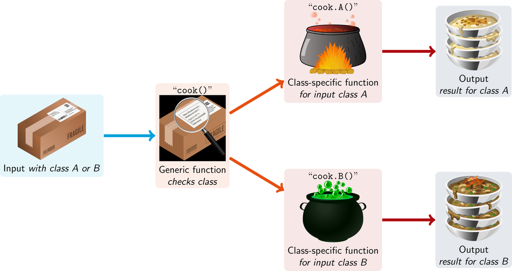

## Behind the Scenes: the function.class structure

- If you start typing the `summary()` function name in RStudio, you will see that there are actually many summary functions …
- … among which `summary.data.frame()` and `summary.matrix()`
- In principle, we need not bother with the system, but it can be useful to keep in mind for two cases:
1. Help files and documentation may differ depending on classes.
2. Applying it to an object for which the class function has not been defined (*“Why does `summary()` not work on my object X?”*).

## Exercise 3.3: Using the plot function for different objects

1. Remember your vector `x1` of normally distributed random variables created in Exercise 3.2.
2. Make a basic plot of this vector using the simple command `plot(x1)`.
3. Now transform your vector `x1` into a time series object using the function `ts()`. Save it as `x1ts`.
4. Make a plot of this new object using the command `plot(x1ts)`. Why does it look different from before?
5. Make a plot of the variable `Period` from the `courses` data frame. Explain why this looks yet again different.

# Packages

## R packages

- Until now, we have explored some basic functionality in R. But much of the functionality of R is extended by its big and active community.
- These extensions are called **R packages**.
- One of R’s defining features is the richness of its package management system:
  - Packages are constantly developed and adjusted by the large user community making many state-of-the-art methods quickly available
  - Packages can be installed for just about everything you want to do in statistics and data science
  - Packages offer pre-defined functions which makes it possible to use R without a deep understanding of the language and programming skills.

## Overview of R packages

- The standard distribution of R comes already with a number of packages.
- A list of the currently installed packages can be obtained from the *Packages* window in the bottom right window below

[figure not shown]

- You can install new packages depending on your needs

## Installing R packages

- To install a new R package, click on the *Install* button at the top of the *Packages* window.

You can then type the name of the R package you want to install. Let us install the package **this.path**

[figure not shown]

You can use this R code also directly to install a package. The package is now added to to your package list and ready to be used.

```r
install.packages("this.path", dependencies = TRUE)
```

## Loading R package

- Installing an R package as we just did, only needs to be done once.
- Yet each time you want to use the functionality of the R package in your current R session, you need to activate it. You can do this via the following command:

```r
library(this.path)
```

- After activating the package nothing immediately happens, but R simply has access to the functionality that `this.path` offers.

## Using functions from a package without loading the package

- It is also possible to use functions from a package without actually loading the package.
- Although generally you may not want to do this, it can sometimes be useful if you only need a single function; especially for a big package, you don’t need all functions stored in memory.
- This can be done using the command

```r
package_name::function_name()
```

which can be interpreted as “use the function `function_name()` from the package `package_name`.”

## Exercise 3.4: R package

- If you have not yet done, so, install the `this.path` package.
- Why did we install the `this.path` package? Because it offers functionality to set your working directory, as an alternative to the menu-based approach we did before.
- To set the working directory to the folder where your current R script is located, you can simply use:

```r
setwd(this.path::here())
```

- Can you explain every step in this line?
- Can you think of an alternative way to achieve the same thing with the same functions?
- It may be convenient to enter this at the top of your R script to ensure that you are always working in the directory where your R Script is located without having to type the name of the path!

## Digging Deeper into Packages

- We have now seen that installing packages is straightforward. But how do I know which package I need?
- And how do packages function? Do they rely on other packages? Should I be bothered with this?
- Let’s have a deeper look.

## Finding good packages

- Sometimes packages come recommended in books or articles.
- If not, do a Google or ChatGPT search: ‘R package for reading Excel’; top search results are typically the most popular packages.
- Unsure about the quality? Some advice:
  - Consider the authors. Are they respected academics? Or have a good track record of developing packages? These are good signs.
  - Read the manuals / help files. Do they make sense? Are they written by someone who understands the important aspects of the methods?
  - Install and try them, and see if they match your expectations.

## More about packages

- Most of the time you need not need to be bothered by understanding the deeper meanings of the package, and you can just install it directly. But in case you do want to have a look, here are some things you can pay attention to.
- ‘Official’ packages are hosted on the **Comprehensive R Archive Network (CRAN)**.
- The package homepage can be found as **https://cran.r-project.org/package=package_name**
- You can find the same info after installing a package by clicking on the package name, then on *‘DESCRIPTION file’*.
- Important fields:
  - **Maintainer** & **Author**: especially helpful for specialised packages, for which you expect the authors to be experts in the field.
  - **URL**: Is there dedicated documentation? What is the quality of the documentation (often correlates with the quality of the package)?
  - **Imports**, **Depends** & **LinkingTo**: the packages needed to make the package work (installation is normally taken care of automatically).
  - **Suggests**: packages that are not necessarily needed for using the package, but are needed for specific functionalities.

## Checking out the bootUR package

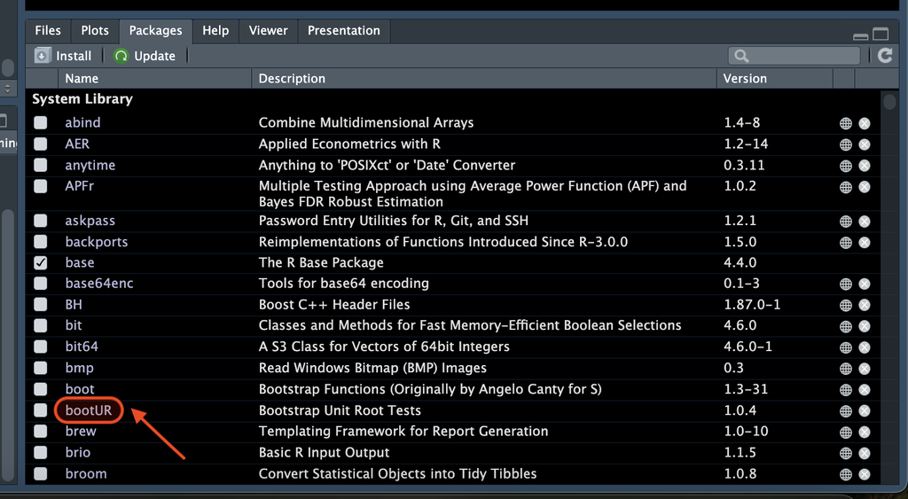

## Checking out the bootUR package

[figure not shown]

## Checking out the bootUR package

[figure not shown]

## Suggested packages

- It is up to the author to decide what packages to suggest, and what packages to list as imports.
- It is also up to the author to protect the user from strange error messages while not having installed a suggested package.
- This is not always done properly!
- Suggested packages are not always installed automatically!

## Installing suggested packages

- The command

```r
install.packages("package-name")
```

does not install suggested packages. Use instead

```r
install.packages("package-name", dependencies = TRUE)
```

- In RStudio, make sure that the box “Install dependencies” is checked.

## Bonus Exercise 3.5: Package information & installation

1. Find out who the maintainer is of the package `bigtime`.
2. Check if you have the suggested packages for `bootUR` installed. If you have `ggplot2` installed, remove it from your installation. (This can be done by clicking at the right spot in RStudio’s Packages tab.)
3. Install the package `bootUR` in the ‘naive’ way using `install.packages("bootUR")`.
4. This package has a function to plot missing values in a time series dataset; apply this function to the data set that comes with the package. (This obviously implies you need to find both the function and the dataset.)
5. You will get an error message. Fix the error and repeat the steps above to produce a plot of the missing values.

## Bonus: Installing packages from (other) source(s)

- Sometimes you might find a package not available on CRAN, but hosted on different platforms, such as GitHub.
- Such packages have to be installed from ‘source’.
- Occasionally, CRAN may also ask you if you want to install a package from source, if a newer version is available than the standard binary package.
- Installing from source is problematic on Windows and Mac, as it requires the installation of additional software for packages that are built on C/C++/Fortran code that needs compilation (see e.g. `?install.packages` for details).
- Advice for beginners: do not install from source!

## Bonus Exercise 3.6: Installing packages from source

**Important**

This exercise should only be completed if you feel up for a challenge and want to get your system ready for installing from source. Please SKIP unless you know what you are doing!

1. Go to https://github.com/Marga8/HDGCvar and follow the installation instructions to install the package `HDGCvar` from source. This should work on all systems.
2. Go to https://github.com/RobertAdamek/desla and follow the installation instructions to install the package `desla` from source.

**Caution**

This will most likely not work and result in errors.

3. Go to https://github.com/smeekes/bootUR and read the extended installation instructions for installing from source. Install the missing software and then try to install the package `desla` again.

**Warning**

On Windows, this should be relatively safe, but on Mac things still can go wrong. Be warned.